# HW3

Matthew Jensen

2024-10-31

# **Part 1**

## Problem 1.

### a.

$$\text{Classifier: } 2x_1 + 3x_2 - 4 = 0$$

#### Predicted Labels

$$\text{label = sign(} w \cdot x + b)$$

$$\text{Row 1: sign(} 2(1) + 3(1) -4 ) = \text{sign(} 1) = 1$$
$$\text{Row 2: sign(} 2(1) + 3(-1) -4 = \text{sign(}-5) = -1$$
$$\text{Row 3: sign(} 2(0) + 3(0) -4 = \text{sign(}-4) = -1$$
$$\text{Row 4: sign(} 2(-1) + 3(3) -4 = \text{sign(}3) = 1$$

$$\begin{array}{|c|c|}
\hline
\textbf{Actual Label} & \textbf{Predicted Label} \\
\hline
1 & 1 \\
\hline
-1 & -1 \\
\hline
-1 & -1 \\
\hline
1 & 1 \\
\hline
\end{array}$$
#### Margin

$$\text{Margin = min ( } \frac{( y_i(w \cdot x + b))}{||w||}) =
\frac{1}{||w||}$$
$$\frac{1}{||w||} = \frac{1}{\sqrt{2^2 + 3^2}} = \frac{1}{\sqrt{13}}
\approx .277$$

### b

$$\text{Row 4: sign(} 2(-1) + 3(-1) -4 = \text{sign(}-9) = -1$$
$$\begin{array}{|c|c|}
\hline
\textbf{Actual Label} & \textbf{Predicted Label} \\
\hline
1 & 1 \\
\hline
-1 & -1 \\
\hline
-1 & -1 \\
\hline
1 & 1 \\
\hline
\hline
1 & -1 \\
\hline
\end{array}$$
$$\textbf{No. Because the last point is misclassified, there is not a
margin for this hyperplane.}$$

## **Problem 2.**

### a.

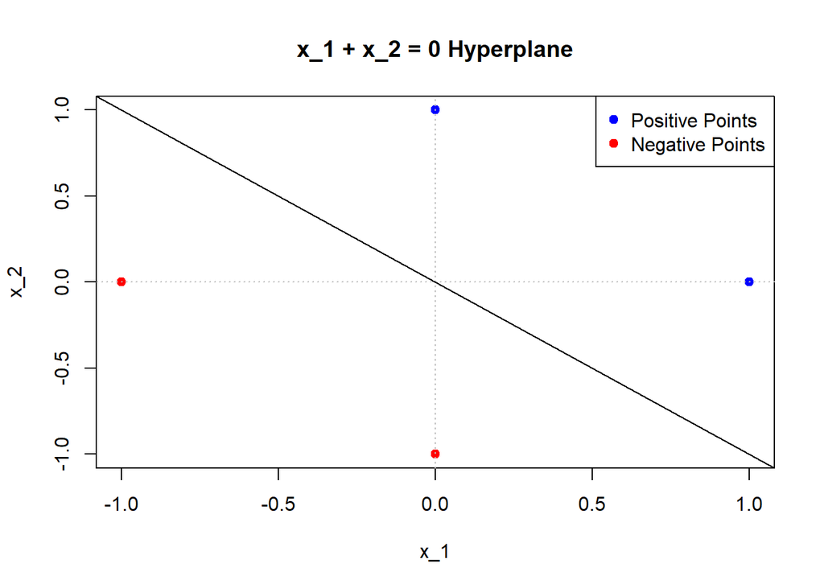

#### b.

$$\text{There is no linear classifier that correctly seperate all the
points in this dataset and thus, there } \textbf{no margin} \text{ for
this dataset.}$$

## **Problem 3.**

## Mistake Bound Theorem for Perceptron

We are given a training dataset $\{ (x_i, y_i) \}_{i=1}^m$ where $x_i \in \mathbb{R}^n$ and $y_i \in \{-1, +1\}$. We assume that there exists a vector $u \in \mathbb{R}^n$ and a positive margin $\gamma$ such that:

$$y_i (u^T x_i) \geq \gamma \quad \text{for all } i = 1, 2, \dots, m$$

Our goal is to show that the number of mistakes made by the Perceptron algorithm is bounded by:

$$\frac{\| w^* \|^2}{\gamma^2}$$

where $w^*$ is any vector that can separate the data with margin $\gamma$.

### Proof

1. **Initialize** the Perceptron algorithm with $w = 0$.
2. **Define Mistakes**: Let $M$ be the total number of mistakes made by the Perceptron algorithm. For each mistake, the weight vector $w$ is updated as follows:

   $$w = w + y_i x_i$$

   After $M$ mistakes, the resulting weight vector $w_M$ can be written as the sum of the updates:

   $$w_M = \sum_{j=1}^M y_{i_j} x_{i_j}$$

   where $i_j$ represents the index of the example that was misclassified on the $j$-th mistake.
3. **Bounding $w_M \cdot u$**:

   Since each example satisfies $y_i (u^T x_i) \geq \gamma$, we have:

   $$y_{i_j} (u^T x_{i_j}) \geq \gamma$$

   Thus, the dot product $w_M \cdot u$ can be bounded as follows:

   $$w_M \cdot u = \left( \sum_{j=1}^M y_{i_j} x_{i_j} \right) \cdot u =
   \sum_{j=1}^M y_{i_j} (u^T x_{i_j}) \geq M \gamma$$
4. **Bounding $\| w_M \|$**:

   On each update, we add $y_i x_i$ to $w$, so:

   $$\| w_{j+1} \|^2 = \| w_j + y_{i_j} x_{i_j} \|^2$$

   Expanding this:

   $$\| w_{j+1} \|^2 = \| w_j \|^2 + 2 y_{i_j} (w_j \cdot x_{i_j}) + \|
   x_{i_j} \|^2$$

   Since $w_j$ misclassifies $x_{i_j}$, we have $y_{i_j} (w_j \cdot x_{i_j}) \leq 0$. Therefore:

   $$\| w_{j+1} \|^2 \leq \| w_j \|^2 + \| x_{i_j} \|^2$$

   Assuming each $x_i$ has a bounded norm $\| x_i \| \leq R$, it follows that:

   $$\| w_M \|^2 \leq M R^2$$
5. **Combining Inequalities**:

   From Step 3, we have $w_M \cdot u \geq M \gamma$, and from Step 4, we have $\| w_M \| \leq \sqrt{M} R$. Using the Cauchy-Schwarz inequality, we obtain:

   $$w_M \cdot u \leq \| w_M \| \| u \| \leq R \| u \| \sqrt{M}$$

   Combining these:

   $$M \gamma \leq R \| u \| \sqrt{M}$$
6. **Solving for $M$**:

   Dividing both sides by $\sqrt{M} \gamma$, we get:

   $$\sqrt{M} \leq \frac{R \| u \|}{\gamma}$$

   Squaring both sides gives:

   $$M \leq \frac{R^2 \| u \|^2}{\gamma^2}$$

### Conclusion

The Perceptron algorithm makes at most $\frac{R^2 \| u \|^2}{\gamma^2}$ mistakes.

### **Problem 4**

## Mistake Bound Theorem

Given that the Mistake Bound Theorem for the Perceptron algorithm states:

$$M \leq \frac{||R||^2 \|u\|^2}{\gamma^2}$$

where: - $R$ is the maximum norm of any input vector $x_i$, - $\| u \|$ is the norm of a weight vector $u$ that correctly classifies all inputs with margin $\gamma$.

### Applying the Bound to Our Disjunction Function

For the function $f(x_1, x_2, \dots, x_n) = \neg x_1 \vee \neg x_2 \vee \dots \vee \neg x_k \vee x_{k+1} \vee \dots \vee x_{2k}$:

1. **Maximum Norm $R$:** Since each input vector is a Boolean vector ($x_i \in \{0, 1\}$), the maximum norm $R$ is $\sqrt{n}$.
2. **Weight Vector $u$:** We can construct $u$ to match the function structure, setting:
   - $-1$ for the first $k$ positions (for $\neg x_1, \dots, \neg x_k$),
   - $+1$ for the next $k$ positions (for $x_{k+1}, \dots, x_{2k}$),
   - $0$ for the remaining entries.

   Then, $\| u \| = \sqrt{2k}$.
3. **Margin $\gamma$:** Assume a margin of $\gamma = 1$ for simplicity.

### Calculating the Upper Bound

Substituting these values into the mistake bound formula:

$$M \leq \frac{(\sqrt{n})^2 \cdot (\sqrt{2k})^2}{1^2}$$

This simplifies to:

$$M \leq 2nk$$

### Conclusion

The Perceptron algorithm will make at most $2nk$ mistakes when learning this disjunction function.

### **Problem 5**

#### **Proof by Contradiction**

For a linear classifier to shatter $n$ points, it must correctly classify all possible labels for those points.For 4 points, there are $2^4 = 16$ possible labels.

Let’s consider a 2D classifier, that splits positive and negative points with a hyperplane.

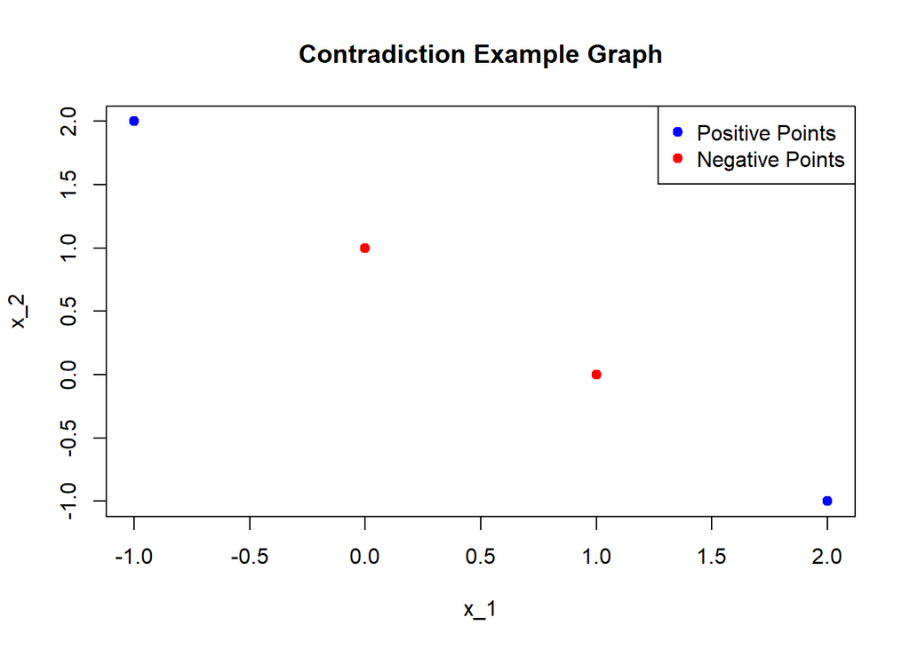

In this example, all 4 points are collinear, and thus, there is no linear classifier that can separate these points correctly based on their labels.

Since we cannot achieve all 16 possible labels for 4 collinear points, a linear classifier in a plane cannot shatter 4 distinct collinear points.

### **Problem 6**

The VC Dimension is the maximum number of points that a hypothesis classifier $H$ can shatter.

Each hypothesis classifier is a rectangle, where all the points with positive labels are within the center of the rectangle and all the points with negative labels are outside.

For 1 point: A single point can be classified as positive or negative by placing a rectangle around it or not. So, $H$ can shatter 1 point. For 2 points: We can cover each point individually or neither or both, so $H$ can shatter 2 points. For 3 points: A rectangle can still cover any subset of three points in the plane, so $H$ can shatter 3 points. For 4 points: For any arrangement of 4 points in general position (not in a line or collinear), it is possible to find a rectangle for every subset of points, meaning 4 points can be shattered. For 5 points: However, with 5 points, it becomes impossible to achieve every possible labeling by placing a single rectangle around any subset of the points. For instance, there may be no way to enclose an arbitrary subset of 5 points in a way that matches every possible labeling.

Therefore, the VC dimension VC(H) for the hypothesis class of all rectangles in a 2D plane is 4.

# **Part 2**

## a.

- Perceptron Weights: [-1.2333106, -0.7830138, -0.87618231, -0.17396738]
- Perceptron Bias: 1.0800000000000005
- Average Train Error: 0.5555683122847302
- Average Test Error: 0.5531062124248497